# Jo-AnonymousPeerInfluenceAppendix-2025-JCR.pdf

Converted from PDF `Jo-AnonymousPeerInfluenceAppendix-2025-JCR.pdf` · 29 pages · anchors: page `#pN`, block `#pN-bK`

Page 1

1

#### In the Company of Strangers:

#### Social Influence from Anonymous Peers in Online Game Settings

Wooyong Jo

Sarang Sunder

Jeonghye Choi

Minakshi Trivedi

#### **Table of Contents**

*A. Additional Information on Social Match Setups*

*B. Use of Control Function to Interaction Term with Endogenous Variable*

*C. Results of First-stage Regressions*

*D. Full Results of Mechanism Analyses (Table 4)*

*E. Robustness Check: Alternative Operationalization of Peer Exposure (Dynamic Perspective)*

*F. Robustness Check: Full Results of Cragg’s Two-part Hurdle Model*

*G. Robustness Check: Additional Tests of Competitive Concern*

*H. Robustness Check: Alternative Sampling Criteria*

*I. Robustness Check: Test for Normative Influence*

*J. Robustness Check: Alternative Functional Form (Poisson Fixed Effects Model)*

K. *Robustness Check: Need for Reloading Game Items*

L. *Heterogeneity in Item Salience*

Page 2

2

#### **WEB APPENDIX A: Additional Information on Social Match Setups**

*A1. Potential Imbalance in Match Formation*

Figure A1: Social Match Set-ups by User Expertise—Heat Map

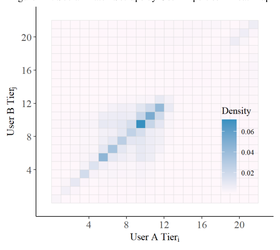

NOTE: figure/graphic rendered as an image from the PDF; its content is not machine-readable text. Caption (if any) follows as the next block.

To illustrate the social match setups in Figure 2, we plot a heatmap-style representation with a density legend. This figure further suggests the potential endogenous formulation of social matches by user tier (45-degree line). We address this issue by using non-overlapping peers in an intransitive peer network (refer to our METHODOLOGY section for details).

Page 3

3

*A2. User Tier Distribution by Weekly Social Match Participation Status*

Figure A2 illustrates the overall pattern of user tiers in a user-week panel dataset (original sample of 4,000 users), conditioned by social match participation. Notably, while the overall shape of the distribution appears similar, the subset of user tiers with no social match participation (Figure A2.B) shows a greater concentration of observations in the lower tiers (below five).

This pattern supports our cautious empirical approach, suggesting that there could be potential selection issues related to social match participation. As noted in the manuscript, we address this issue directly by explicitly modeling social match participation through an IV approach.

Figure A2: Breakdown of Tier Distribution by Social Match Participation

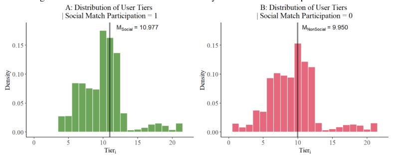

NOTE: figure/graphic rendered as an image from the PDF; its content is not machine-readable text. Caption (if any) follows as the next block.

Note: Color is available online. Vertical lines denote the mean values of distributions.

Page 4

4

#### **WEB APPENDIX B:**

#### **Use of Control Function to Interaction Term with Endogenous Variable**

The control function approach offers advantages over the standard instrumental variable approach, particularly when dealing with interactions (Papies, Ebbes and Van Heerde 2017; Wooldridge 2015). The inclusion of the control function offers a robust method to address potential endogeneity in both the primary regressor and its interaction terms. Theoretically, the origin of the potential endogeneity in the interaction term can be traced back to the main endogenous variable. This is because the interaction term is essentially a product of the main variable and another variable. If the main variable is endogenous, this endogeneity will naturally propagate to the interaction term.

However, the control function, by construction, captures and corrects for the endogenous components of the main variable. Consequently, when the control function adjusts for the endogeneity in the main variable, it also inherently corrects for the endogeneity present in the interaction term. Thus, the control function does not need to be interacted with moderators (See also Han, Mittal and Zhang 2017; Shen and Xiao 2014). A detailed mathematical illustration of this concept is provided below.

As in our context, suppose that we are interested in estimating 𝛽 in the following equation:

𝑦𝑖𝑡= 𝛼𝑖+ 𝜏𝑡+ 𝛽𝑥𝑖𝑡+ 𝛾𝐙𝐢𝐭+ 𝜀𝑖𝑡 B.(1)

**equation / math rendering (image)**

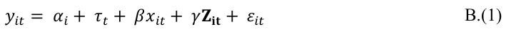

NOTE: contains mathematical notation; text above is the PDF text layer and symbols may be mis-extracted. Image shows the original.

• 𝑦𝑖𝑡 is the spending observed for user i in week t. • 𝛼𝑖 is the user fixed effect. • 𝜏𝑡 is the week fixed effect. • 𝑥𝑖𝑡 is the peer exposure for user i in week t-1. (potentially endogenous) • 𝐙𝐢𝐭 is a vector of control variables. • 𝜀𝑖𝑡 is the error term.

Now, suppose we identify a strong and valid instrument—in our case, average purchases of peers of peersit-2—and estimate the first-stage regression. Specifically, we first identify all the nonoverlapping peers of focal player 𝑖 using the social match logs of each week. That is, we trace back to the peers of the focal player in week 𝑡-1. Then, we find the **other peers that these peers interacted** with in week 𝑡-2, find their purchases in week 𝑡-2, and take the average values. The specific results of this estimation are provided in Table C2 of Web Appendix C.

From this regression, we derive a control function, or residual, by subtracting the fitted value (𝑥̂𝑖𝑡) from the actual value(𝑥𝑖𝑡).

𝑉̂𝑖𝑡= 𝑥𝑖𝑡− 𝑥̂𝑖𝑡 B.(2)

**equation / math rendering (image)**

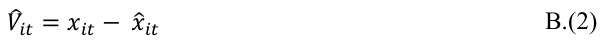

NOTE: contains mathematical notation; text above is the PDF text layer and symbols may be mis-extracted. Image shows the original.

Page 5

5

The completed second-stage model involves adding the control function (𝑉̂𝑖𝑡) as an additional regressor to the main model. This can be expressed as follows:

𝑦𝑖𝑡= 𝛼𝑖+ 𝜏𝑡+ 𝛽𝑥𝑖𝑡+ 𝛾𝐙𝐢𝐭+ 𝜃𝑉̂𝑖𝑡+ 𝜀𝑖𝑡 B.(3)

**equation / math rendering (image)**

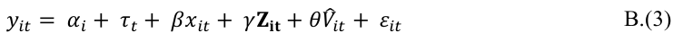

NOTE: contains mathematical notation; text above is the PDF text layer and symbols may be mis-extracted. Image shows the original.

𝑦𝑖𝑡= 𝛼𝑖+ 𝜏𝑡+ 𝛽𝑥𝑖𝑡+ 𝛾𝐙𝐢𝐭+ 𝜃(𝑥𝑖𝑡− 𝑥̂𝑖𝑡) + 𝜀𝑖𝑡 B.(4)

**equation / math rendering (image)**

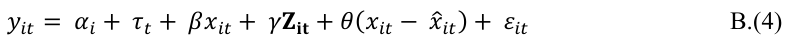

NOTE: contains mathematical notation; text above is the PDF text layer and symbols may be mis-extracted. Image shows the original.

𝑦𝑖𝑡= 𝛼𝑖+ 𝜏𝑡+ (𝛽+ 𝜃)𝑥𝑖𝑡+ 𝛾𝐙𝐢𝐭−𝜃𝑥̂𝑖𝑡+ 𝜀𝑖𝑡 B.(5)

**equation / math rendering (image)**

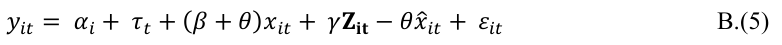

NOTE: contains mathematical notation; text above is the PDF text layer and symbols may be mis-extracted. Image shows the original.

The final equation (5) indicates that when the control function is included, the estimated coefficient of 𝑥𝑖𝑡 changes from 𝛽 to (𝛽+ 𝜃). Empirically, 𝜃 is the estimated coefficient of the control function, demonstrating that 𝜃 directly adjusts the magnitude of the estimated effect of the endogenous regressor.

Now, suppose we introduce an additional regressor, ℎ𝑖𝑡, and create an interaction with the endogenous regressor. For example, this new regressor could be the variables we use to test underlying mechanisms, such as contextual knowledge or threats to status. The equation then evolves as follows:

𝑦𝑖𝑡= 𝛼𝑖+ 𝜏𝑡+ 𝛽𝑥𝑖𝑡+ 𝜓ℎ𝑖𝑡+ 𝜙𝑥𝑖𝑡ℎ𝑖𝑡 + 𝛾𝐙𝐢𝐭+ 𝜃𝑉̂𝑖𝑡+ 𝜀𝑖𝑡 B.(6)

**equation / math rendering (image)**

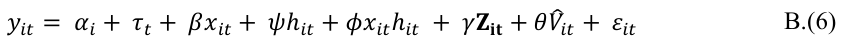

NOTE: contains mathematical notation; text above is the PDF text layer and symbols may be mis-extracted. Image shows the original.

An important question here is if the inclusion of a control function accounts for potential endogeneity in the interaction term 𝑥𝑖𝑡ℎ𝑖𝑡. The equation can be reformulated as follows:

𝑦𝑖𝑡= 𝛼𝑖+ 𝜏𝑡+ (𝛽+ 𝜙ℎ𝑖𝑡)𝑥𝑖𝑡+ 𝜓ℎ𝑖𝑡+ 𝛾𝐙𝐢𝐭+ 𝜃𝑉̂𝑖𝑡+ 𝜀𝑖𝑡 B.(7)

**equation / math rendering (image)**

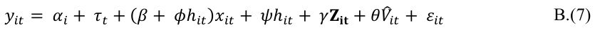

NOTE: contains mathematical notation; text above is the PDF text layer and symbols may be mis-extracted. Image shows the original.

Here, the term (𝛽+ 𝜙ℎ𝑖𝑡) captures the combined effect of the main influence of 𝑥𝑖𝑡 and its interaction with ℎ𝑖𝑡. If we further reformulate the equation, it becomes:

𝑦𝑖𝑡= 𝛼𝑖+ 𝜏𝑡+ (𝛽+ 𝜙ℎ𝑖𝑡+ 𝜃)𝑥𝑖𝑡+ 𝜓ℎ𝑖𝑡+ 𝛾𝐙𝐢𝐭−𝜃𝑥̂𝑖𝑡+ 𝜀𝑖𝑡 B.(8)

**equation / math rendering (image)**

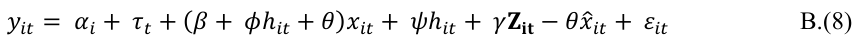

NOTE: contains mathematical notation; text above is the PDF text layer and symbols may be mis-extracted. Image shows the original.

Here, it is clear that the combined influence of both the main effect and the interaction, represented by (𝛽+ 𝜙ℎ𝑖𝑡+ 𝜃), is adjusted by 𝜃 in the same manner as observed for the main effect.

Page 6

6

#### **WEB APPENDIX C: Results of First-stage Regressions**

*C.1. Selection Model of Social Match Participation*

We present the empirical results of the first-stage regression on social match participation using an instrumental variable (IV). Our IV consists of two components: 𝑁𝑖𝑔ℎ𝑡𝑃𝑙𝑎𝑦𝑃𝑜𝑟𝑡𝑖𝑜𝑛𝑖, which computes the ratio of total gameplay minutes during the night (from 6:00 PM – 6:00 AM) to the total gameplay minutes, and 𝑆𝑒𝑟𝑣𝑒𝑟𝐷𝑜𝑤𝑛𝑡, a binary indicator of unexpected game server outages for maintenance.

Potential concerns in the use of this IV include: (1) the possibility of a degenerate condition where the IV has no variation at all during the entire observation period. This could occur if a user has a zero value in 𝑁𝑖𝑔ℎ𝑡𝑃𝑙𝑎𝑦𝑃𝑜𝑟𝑡𝑖𝑜𝑛𝑖. However, we find this is unlikely because only 3 out of 3,699 players (.08%) have an exactly zero value for this variable. Figure C below depicts the distribution of this cross-sectional variation among the sample, with a mean of .585 and a standard deviation of .161, as shown.

Figure C: Distribution of 𝑁𝑖𝑔ℎ𝑡𝑃𝑙𝑎𝑦𝑃𝑜𝑟𝑡𝑖𝑜𝑛𝑖 Variable

**equation / math rendering (image)**

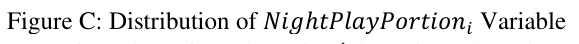

NOTE: contains mathematical notation; text above is the PDF text layer and symbols may be mis-extracted. Image shows the original.

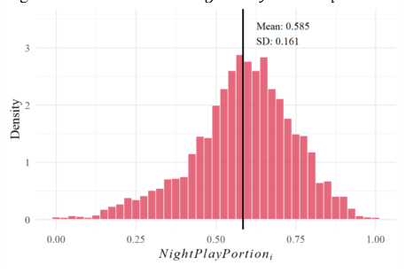

NOTE: figure/graphic rendered as an image from the PDF; its content is not machine-readable text. Caption (if any) follows as the next block.

Note: Color is available online. The vertical bar denotes the position of the mean value. Another concern may be that 𝑁𝑖𝑔ℎ𝑡𝑃𝑙𝑎𝑦𝑃𝑜𝑟𝑡𝑖𝑜𝑛𝑖 is at least partially endogenous to the error term. Specifically, the propensity to play the game at night may be correlated with how much money each player spends weekly. However, this concern is substantially mitigated because, in the first-stage regression, we use a random effects Probit model, where player-level random effects absorb the influence of such unobserved factors.

The more explanation of the IV and the identification assumptions are discussed in the METHODOLOGY section. Here, we report the detailed results for (1) the relevance and (2) the exclusion restriction conditions of the IV for identifying the effect of interest.

*Relevance*. To assess the empirical strength of our instrumental variable (IV), we estimate a firststage random effect Probit model using the social match participation dummy variable as the dependent variable. We include the IV along with a set of control variables that are similar to

Page 7

7

those used in our main analysis. Table C1 reports estimation results. Our analysis reveals that the IV has a negative and statistically significant effect on a player’s decision to participate in social matches each week (𝛽= −. 319, 𝑝< .05). In addition, we perform a likelihood ratio test both with and without the instrument to examine potential weak instrument issues. The results of the likelihood ratio test suggest that the model fit improves significantly (*p* < .01) with the inclusion of the IV (Gu and Kannan 2021; Haviv, Huang and Li 2020).

Table C1: Selection into Social Matches—IV Approach *Model Full Model Restricted Model Variable Estimate S.E. Estimate S.E.* **Instrument it-1** -.319 ** .128

| Mod el | FullMod el |  | Restricted Mod el |
| --- | --- | --- | --- |
| Variabl e | Estimate | S E . . | Estimate S E . . |
| Instrument it-1 | 319** -. | 128 . |  |
| Visit frequencyit-1 | 1 753*** . | 020 . | 1 752*** 020 . . |
| Weekends play portion it-1 | 058 . | 037 . | 059 037 . . |
| Night play portion it-1 | 174*** -. | 032 . | 175*** 032 -. . |
| Age it-12 | 132*** -. | 041 . | 131*** 041 -. . |
| Age it-1 | 801*** . | 260 . | 789*** 260 . . |
| Tenure it-1 | 200*** . | 057 . | 200*** 057 . . |
| Precipitation it-1 | 009 . | 009 . | 008 009 . . |
| Intercept | 4 588*** - . | 420 . | 4 565*** 420 - . . |
| User random effects | Included |  | Included |
| Weekly time dummies | Included |  | Included |
| Observations | 118 368 , |  | 118 368 , |
| Log-likelihood | 34249434 - , . |  | 34254257 - , . |
| Δ2𝐿𝐿 (orDeviance) | 96462*** . |  |  |

NOTE: table converted from PDF layout to HTML text; cell boundaries are reconstructed. See PDF if exact alignment matters.

Note: *p<.10; **p<.05; ***p<.01. Standard errors are clustered at the user level.

*Exclusion*. Another essential criterion for a valid instrument is the exclusion restriction, which indicates that the instrument should be correlated with target dependent variable solely through its relationship with the endogenous variable (i.e., social match participation). To test for the exogeneity of our IV, we follow the exclusion test proposed by Barron, Kung, and Proserpio (2021). Specifically, if our instrument is valid, we should observe **no change in purchase activities among players who did not participate in social matches** in response to the instrument. To confirm this, we regressed the weekly purchase amount (i.e., the dependent variable in our main analysis) on the instrument, focusing on the sample of player-week observations without social match participation. From this regression, we find no significant relationship between our instrument and the dependent variable (𝛽= .023;𝑝> .10). This result demonstrates the validity of our IV as a tool for accounting for the selection process into social matches using solely exogenous variation in the data.

We calculate the inverse Mills ratio (IMR, hereafter) based on the full model presented in Table C1 and include it as an additional regressor in all analyses performed in the manuscript. IMR effectively accounts for the selection bias associated with participating or not participating in

Page 8

8

social matches when estimating peer influence. However, we also retain the control function approach, as it accounts for continuous variation in the peer exposure variable, conditional on social match participation.

| Variable | Estimate | S E . . |
| --- | --- | --- |
| Purchases of peers of peersit-2 (Instrument) | 500*** . | 007 . |
| Visit frequencyit-1 | 261*** . | 006 . |
| Weekends play portionit-1 | 100*** -. | 009 . |
| Night play portionit-1 | 153*** -. | 007 . |
| Ageit2 | 079 . | 096 . |
| Ageit | 427 -. | 504 . |
| Tenureit | 043** . | 013 . |
| Precipitationit | 001 . | 002 . |
| IMR SelectionCorrectionforSocialMatchParticipation it-1 | 268*** . | 009 . |
| Individual FixedEffects | Included |  |
| Weekly Fixed Effects | Included |  |
| R squared | 694 . |  |

NOTE: table converted from PDF layout to HTML text; cell boundaries are reconstructed. See PDF if exact alignment matters.

As with our social match participation model, we examine whether the instrument impacts the focal user’s spending solely through its influence on peers’ spending, known as the exclusion restriction. Following the approach outlined by Barron et al. (2021), we test the validity of our

Page 9

9

instrument using only users who interacted with anonymous peers that had zero spending. If our instrument is valid, we should not observe a significant relationship between the instrument and the focal user’s spending for this subset. Consistent with this expectation, we find that the instrument does not significantly influence the focal user’s spending (𝛽 = .002; p >.10), thereby confirming the exclusion restriction.

Page 10

10

#### **WEB APPENDIX D: Full Results of Mechanism Analyses (Table 4)**

Table D1: Operationalization of Key Moderators Operationalization of Table Model Contextual Knowledge Threats to Status Table D2 (1) Cum. Game Visitsit-1 % Inferior matchit-1 (𝑅𝑖𝑡−1 < 𝑅𝑗𝑡−1) Table D2 (2) Cum. Social Matchesit-1 % Inferior matchit-1 (𝑅𝑖𝑡−1 < 𝑅𝑗𝑡−1) Table D2 (3) Tenureit % Inferior matchit-1 (𝑅𝑖𝑡−1 < 𝑅𝑗𝑡−1) Table D3 (4) Cum. Game Visitsit-1 % Inferior matchit-1 (𝑅𝑖𝑡−1 + 1 < 𝑅𝑗𝑡−1) Table D3 (5) Cum. Social Matchesit-1 % Inferior matchit-1 (𝑅𝑖𝑡−1 + 1 < 𝑅𝑗𝑡−1) Table D3 (6) Tenureit % Inferior matchit-1 (𝑅𝑖𝑡−1 + 1 < 𝑅𝑗𝑡−1) Table D4 (7) Cum. Game Visitsit-1 % Inferior matchit-1 (𝑅𝑖𝑡−1 + 2 < 𝑅𝑗𝑡−1) Table D4 (8) Cum. Social Matchesit-1 % Inferior matchit-1 (𝑅𝑖𝑡−1 + 2 < 𝑅𝑗𝑡−1) Table D4 (9) Tenureit % Inferior matchit-1 (𝑅𝑖𝑡−1 + 2 < 𝑅𝑗𝑡−1)

|  |  | Operationalizationof |  |
| --- | --- | --- | --- |
| Table | Model | ContextualKnowledge | ThreatstoStatus |
| TableD2 | (1) | Cum Game Visitsit-1 . | % Inferior match it-1 |
| TableD2 | (2) | Cum Social Matchesit-1 . | (𝑅 < 𝑅 ) 𝑖𝑡−1 𝑗𝑡−1 % Inferior match it-1 |
| TableD2 | (3) | Tenureit | (𝑅 < 𝑅 ) 𝑖𝑡−1 𝑗𝑡−1 % Inferior match it-1 |
| TableD3 | (4) | Cum Game Visitsit-1 . | (𝑅 < 𝑅 ) 𝑖𝑡−1 𝑗𝑡−1 % Inferior match it-1 |
| TableD3 | (5) | Cum Social Matchesit-1 . | (𝑅 +1 < 𝑅 ) 𝑖𝑡−1 𝑗𝑡−1 % Inferior match it-1 |
| TableD3 | (6) | Tenureit | (𝑅 +1 < 𝑅 ) 𝑖𝑡−1 𝑗𝑡−1 % Inferior match it-1 |
| TableD4 | (7) | Cum Game Visitsit-1 . | (𝑅 +1 < 𝑅 ) 𝑖𝑡−1 𝑗𝑡−1 % Inferior match it-1 |
| TableD4 | (8) | Cum Social Matchesit-1 . | (𝑅 +2 < 𝑅 ) 𝑖𝑡−1 𝑗𝑡−1 % Inferior match it-1 |
| TableD4 | (9) | Tenureit | (𝑅 +2 < 𝑅 ) 𝑖𝑡−1 𝑗𝑡−1 % Inferior match it-1 (𝑅 +2 < 𝑅 ) 𝑖𝑡−1 𝑗𝑡−1 |

NOTE: table converted from PDF layout to HTML text; cell boundaries are reconstructed. See PDF if exact alignment matters.

Table D2: Full Results Mechanism Analyses: Model (1)—(3) Model (1) (2) (3) Variables Est. S.E. Est. S.E. Est. S.E. Peer exposureit-1 (PE) .059 ***.012 .074***.012 .057 ***.013 PE × Contextual Knowledge -.010 * .005 -.006* .003 -.017 ** .006 PE × Threats to Status -.005 .020 -.002 .020 -.007 .020 Contextual Knowledge -.067 ***.010 -.027***.006 N/A Threats to Status .182 ***.041 .182***.040 .184 ***.043 Visit frequencyit-1 .170 ***.008 .155***.009 .149 ***.009 Weekends play portionit-1 .088 ***.013 .089***.014 .092 ***.013 Night play portionit-1 -.030 * .012 -.033** .012 -.033 ** .012 Ageit<sup>2</sup> -.212 .185 -.197 .175 -.197 .193 Ageit 1.140 .958 1.020 .937 1.033 1.015 Tenureit -.071 ** .026 -.063* .027 -.052 .029 Precipitationit .001 .004 .001 .003 .001 .004 IMRit-1 -.013 .009 -.014 .010 -.015 .010 Control functionit-1 -.015 .013 -.025* .013 -.017 .014 R squared .279 .279 .278 Note: N=118,368. All models include individual and weekly time fixed effects. Bootstrapped standard errors with 200 resamples are used. All moderators are mean-centered. *p<.05; **p<.01; ***p<.001.

| Model | (1) |  | (2) |  | (3) |  |
| --- | --- | --- | --- | --- | --- | --- |
| Variables | Est . | S E . . | Est . | S E . . | Est . | S E . . |
| Peer exposureit-1 (PE) | 059*** . | 012 . | 074*** . | 012 . | 057*** . | 013 . |
| PE × Contextual Knowledge | 010* -. | 005 . | 006* -. | 003 . | 017** -. | 006 . |
| PE × Threats toStatus | 005 -. | 020 . | 002 -. | 020 . | 007 -. | 020 . |
| Contextual Knowledge | 067*** -. | 010 . | 027*** -. | 006 . | N/A |  |
| Threats to Status | 182*** . | 041 . | 182*** . | 040 . | 184*** . | 043 . |
| Visit frequencyit-1 | 170*** . | 008 . | 155*** . | 009 . | 149*** . | 009 . |
| Weekends play portionit-1 | 088*** . | 013 . | 089*** . | 014 . | 092*** . | 013 . |
| Night play portionit-1 | 030* -. | 012 . | 033** -. | 012 . | 033** -. | 012 . |
| Ageit2 | 212 -. | 185 . | 197 -. | 175 . | 197 -. | 193 . |
| Ageit | 1 140 . | 958 . | 1 020 . | 937 . | 1 033 . | 1 015 . |
| Tenureit | 071** -. | 026 . | 063* -. | 027 . | 052 -. | 029 . |
| Precipitationit | 001 . | 004 . | 001 . | 003 . | 001 . | 004 . |
| IMR it-1 | 013 -. | 009 . | 014 -. | 010 . | 015 -. | 010 . |
| Control functionit-1 | 015 -. | 013 . | 025* -. | 013 . | 017 -. | 014 . |
| R squared | 279 . |  | 279 . |  | 278 . |  |

NOTE: table converted from PDF layout to HTML text; cell boundaries are reconstructed. See PDF if exact alignment matters.

Page 11

11

Table D3: Full Results Mechanism Analyses: Model (4)—(6) Model (4) (5) (6) Variables Est. S.E. Est. S.E. Est. S.E. Peer exposureit-1 (PE) .066 ***.012 .082***.012 .065 ***.012 PE × Contextual Knowledge -.009 * .004 -.006* .003 -.015 * .008 PE × Threats to Status .011 .036 .017 .034 .005 .034 Contextual Knowledge -.069 ***.010 -.027***.005 N/A Threats to Status .192 ** .065 .186** .065 .192 ** .065 Visit frequencyit-1 .171 ***.010 .155***.010 .150 ***.009 Weekends play portionit-1 .088 ***.015 .089***.015 .092 ***.014 Night play portionit-1 -.030 * .012 -.033* .013 -.033 ** .012 Ageit<sup>2</sup> -.208 .188 -.191 .190 -.193 .185 Ageit 1.129 1.031 1.003 1.003 1.023 .931 Tenureit -.059 * .028 -.052 .027 -.045 .030 Precipitationit .001 .004 .001 .004 .001 .004 IMRit-1 -.009 .010 -.010 .010 -.011 .010 Control functionit-1 -.023 .013 -.033** .013 -.026 * .013 R squared .279 .279 .278 Note: N=118,368. All models include individual and weekly time fixed effects. Bootstrapped standard errors with 200 resamples are used. All moderators are mean-centered. *p<.05; **p<.01; ***p<.001.

| Model | (4) |  | (5) |  | (6) |  |
| --- | --- | --- | --- | --- | --- | --- |
| Variables | Est . | S E . . | Est . | S E . . | Est . | S E . . |
| Peer exposureit-1 (PE) | 066*** . | 012 . | 082*** . | 012 . | 065*** . | 012 . |
| PE × Contextual Knowledge | 009* -. | 004 . | 006* -. | 003 . | 015* -. | 008 . |
| PE × Threats toStatus | 011 . | 036 . | 017 . | 034 . | 005 . | 034 . |
| Contextual Knowledge | 069*** -. | 010 . | 027*** -. | 005 . | N/A |  |
| Threats to Status | 192** . | 065 . | 186** . | 065 . | 192** . | 065 . |
| Visit frequencyit-1 | 171*** . | 010 . | 155*** . | 010 . | 150*** . | 009 . |
| Weekends play portionit-1 | 088*** . | 015 . | 089*** . | 015 . | 092*** . | 014 . |
| Night play portionit-1 | 030* -. | 012 . | 033* -. | 013 . | 033** -. | 012 . |
| Ageit2 | 208 -. | 188 . | 191 -. | 190 . | 193 -. | 185 . |
| Ageit | 1 129 . | 1 031 . | 1 003 . | 1 003 . | 1 023 . | 931 . |
| Tenureit | 059* -. | 028 . | 052 -. | 027 . | 045 -. | 030 . |
| Precipitationit | 001 . | 004 . | 001 . | 004 . | 001 . | 004 . |
| IMR it-1 | 009 -. | 010 . | 010 -. | 010 . | 011 -. | 010 . |
| Control functionit-1 | 023 -. | 013 . | 033** -. | 013 . | 026* -. | 013 . |
| R squared | 279 . |  | 279 . |  | 278 . |  |

NOTE: table converted from PDF layout to HTML text; cell boundaries are reconstructed. See PDF if exact alignment matters.

Table D4: Full Results Mechanism Analyses: Model (7)—(9) Model (7) (8) (9) Variables Est. S.E. Est. S.E. Est. S.E. Peer exposureit-1 (PE) .066 ***.011 .082***.012 .065 ***.011 PE × Contextual Knowledge -.010 <sup>a</sup> .005 -.006* .003 -.015 * .007 PE × Threats to Status -.001 .043 .007 .037 -.008 .044 Contextual Knowledge -.068 ***.009 -.027***.005 Threats to Status .233 ** .078 .223** .073 .232 ** .077 Visit frequencyit-1 .172 ***.010 .156***.010 .151 ***.009 Weekends play portionit-1 .088 ***.016 .089***.015 .093 ***.014 Night play portionit-1 -.030 * .013 -.033** .012 -.033 ** .012 Ageit<sup>2</sup> -.207 .172 -.190 .208 -.192 .187 Ageit 1.128 .922 1.003 1.094 1.024 .973 Tenureit -.059 * .026 -.051 .028 -.044 .026 Precipitationit .001 .004 .001 .003 .001 .003 IMRit-1 -.009 .010 -.009 .010 -.011 .009 Control functionit-1 -.023 * .012 -.033** .012 -.026 * .012 R squared .279 .278 .278 Note: N=118,368. All models include individual and weekly time fixed effects. Bootstrapped standard errors with 200 resamples are used. All moderators are mean-centered. <sup>a</sup>p=.058 *p<.05; **p<.01; ***p<.001.

| Model | (7) |  | (8) |  | (9) |  |
| --- | --- | --- | --- | --- | --- | --- |
| Variables | Est . | S E . . | Est . | S E . . | Est . | S E . . |
| Peer exposureit-1 (PE) | 066*** . | 011 . | 082*** . | 012 . | 065*** . | 011 . |
| PE × Contextual Knowledge | 010a -. | 005 . | 006* -. | 003 . | 015* -. | 007 . |
| PE × Threats toStatus | 001 -. | 043 . | 007 . | 037 . | 008 -. | 044 . |
| Contextual Knowledge | 068*** -. | 009 . | 027*** -. | 005 . |  |  |
| Threats to Status | 233** . | 078 . | 223** . | 073 . | 232** . | 077 . |
| Visit frequencyit-1 | 172*** . | 010 . | 156*** . | 010 . | 151*** . | 009 . |
| Weekends play portionit-1 | 088*** . | 016 . | 089*** . | 015 . | 093*** . | 014 . |
| Night play portionit-1 | 030* -. | 013 . | 033** -. | 012 . | 033** -. | 012 . |
| Ageit2 | 207 -. | 172 . | 190 -. | 208 . | 192 -. | 187 . |
| Ageit | 1 128 . | 922 . | 1 003 . | 1 094 . | 1 024 . | 973 . |
| Tenureit | 059* -. | 026 . | 051 -. | 028 . | 044 -. | 026 . |
| Precipitationit | 001 . | 004 . | 001 . | 003 . | 001 . | 003 . |
| IMR it-1 | 009 -. | 010 . | 009 -. | 010 . | 011 -. | 009 . |
| Control functionit-1 | 023* -. | 012 . | 033** -. | 012 . | 026* -. | 012 . |
| R squared | 279 . |  | 278 . |  | 278 . |  |

NOTE: table converted from PDF layout to HTML text; cell boundaries are reconstructed. See PDF if exact alignment matters.

Page 12

12

#### **WEB APPENDIX E:**

#### **Robustness Check: Alternative Operationalization of Peer Exposure (Dynamic Perspective)**

Players’ usage of paid game items may not solely depend on purchases made in the previous week but could also originate from purchases made several weeks prior. To account for this, we construct a dynamically aggregated peer exposure variable, employing a weekly discount factor similar to the advertising stock concept commonly used in marketing literature.

Specifically, we computed the stock of cumulative purchases made by peer 𝑗 up until week 𝑡-1 (see equation E.(1) below).

Cum.Purchases ($)𝑗𝑡−1 = Purchase($)𝑗𝑡−1 + 𝜆× Cum. Purchases($)𝑗𝑡−2 E.(1)

**equation / math rendering (image)**

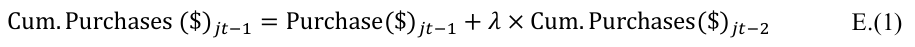

NOTE: contains mathematical notation; text above is the PDF text layer and symbols may be mis-extracted. Image shows the original.

Page 13

13

| Model | (1) | (2) | (3) |
| --- | --- | --- | --- |
| Carryover rate(𝜆)f or cumul ative purch ases | 1 0 . | 0 7 . | 0 5 . |
| Peer Exposureit-1 (PE) b ased on cumul ative purch ases | 220*** . | 404*** . | 438*** . |
| PE it-1 × Contextual Knowledgeit-1 | ( 048) . 011*** -. | ( 086) . 010*** -. | ( 100) . 011*** -. |
|  | ( 002) . | ( 003) . | ( 003) . |
| PE it-1 × Threats to Statusit-1 | 014 -. | 018 -. | 018 -. |
| Contextual Knowledgeit-1 | ( 013) . -.065*** | ( 016) . 067*** -. | ( 018) . 067*** -. |
| Threats to Statusit-1 | ( 010) . 196*** . | ( 010) . 201*** . | ( 011) . 199*** . |
|  | ( 059) . | ( 052) . | ( 054) . |
| Visit frequencyit-1 | 125 -. | 210* -. | 211* -. |
| Weekends play portionit-1 | ( 072) . 182*** . | ( 088) . 214*** . | ( 096) . 215*** . |
| Night play portionit-1 | ( 028) . 117** . | ( 031) . 166*** . | ( 035) . 169** . |
|  | ( 040) . | ( 046) . | ( 051) . |
| Ageit2 | 214 -. | 202 -. | 210 -. |
|  | ( 170) . | ( 188) . | ( 182) . |
| Ageit | 1 212 . | 1 222 . | 1 255 . |
| Tenureit | ( 913) . 109*** -. | ( 966) . 128*** -. | ( 960) . 127*** -. |
|  | ( 027) . | ( 029) . | ( 029) . |
| Precipitationit | 002 . | 001 . | 001 . |
| IMR it-1 | ( 004) . 422*** -. | ( 004) . 520*** -. | ( 004) . 515*** -. |
| Control functionit-1 | ( 099) . 187*** -. | ( 117) . 364*** -. | ( 124) . 396*** -. |
|  | ( 048) . | ( 086) . | ( 101) . |
| Individual fixedeffects | Included | Included | Included |
| Weekly fixed effects | Included | Included | Included |
| R squared | 279 . | 279 . | 279 . |

NOTE: table converted from PDF layout to HTML text; cell boundaries are reconstructed. See PDF if exact alignment matters.

Page 14

14

#### **WEB APPENDIX F:**

#### **Robustness Check: Full Results of Cragg’s Two-part Hurdle Model**

| Dependentvariable | 𝕝( yit > 0) | yit \| yit > 0 |  |
| --- | --- | --- | --- |
| Model | (1):PurchaseIncidence | (2):Purchase | Amount |
| Variables | Estimate SE . . | Estimate | SE . . |
| Peer exposureit-1 | 022*** 004 . . | 005 -. | 042 . |
| Peer exposureit-1 × Know . | -.002 a .001 | 005 . | 010 . |
| Peer exposureit-1× Threat . | 003 006 -. . | 083 . | 052 . |
| ContextualKnowledge(Know) . | -.020 *** .003 | -.208 *** | 044 . |
| ThreatstoStatus(Threat) . | 056*** 013 . . | 087 -. | 109 . |
| Visit frequencyit-1 | 058*** 003 . . | 132** . | 043 . |
| Weekends play portionit-1 | 031*** 005 . . | 108+ . | 057 . |
| Night play portionit-1 | 004 004 -. . | 043 -. | 055 . |
| Ageit2 | 039 065 -. . | 500 . | 794 . |
| Ageit | 237 362 . . | 3039 - . | 4670 . |
| Tenureit | -.023 ** .009 | 042 . | 078 . |
| Precipitationit | 000 001 . . | 008 -. | 012 . |
| IMR it-1 | 007 004 -. . | 025 . | 034 . |
| Control functionit-1 | 009 004 -. . | 003 -. | 043 . |
| Individualfixedeffects | Included | Included |  |
| Weeklyfixedeffects | Included | Included |  |
| Rsquared | 225 . | 498 . |  |
| Observations | 118368 , | 15038 , |  |

NOTE: table converted from PDF layout to HTML text; cell boundaries are reconstructed. See PDF if exact alignment matters.

Observations 118,368 15,038 Note: <sup>a</sup>p=.084; *p<.05; **p<.01; ***p<.001. We use bootstrapped standard errors with 200 resamples. We utilized cumulative visit frequency to measure contextual knowledge and the proportion of inferior social matches as indicators of threats to status. All moderators are centered on their means.

Page 15

15

#### **WEB APPENDIX G:**

#### **Robustness Check: Additional Tests of Competitive Concern**

*G.1. Analyses based on match outcomes*

As we discussed in the manuscript “*Additional test of competitive concern using supplementary data*”, the most salient cue for a status threat in the context of video games is likely the outcome of social matches: winning or losing. Simply speaking, if players lose more frequently, it is reasonable to assume that they would experience an increased threat to their status. If this be the case, it would offer *stronger and more reliable* support to our hypothesis testing regarding competitive concern. Unfortunately, in the main part of our analyses, we were unable to examine variations based on match results due to data limitations (social match outcomes were not the part of provided data). Specifically, the firm confirmed that they retain match result data for only a limited time frame, and this data was not made available to us.

Second, however, we have found alternative data from another collaborative project with the same data provider that includes information on social match results. This data comes from a different sample and time period but offers a more granular level of user behaviors. One downside to this dataset is that it only captures a four-week period. This is consistent with our previous communication with the firm, which indicates that they do not store match results for more than a month due to data management cost considerations. In Table G1, we describe and compare the two datasets. For the sake of clear communication, we refer to the original dataset as “data used in main analysis” and the new dataset as “supplemental new data”.

Table G1: Comparison between Original and New Datasets *Data Scope Data used in main analysis Supplemental “new” Data* Observation period July 2011 to February 2012 November 2012 Duration 32 weeks or eight months 4 weeks or one month Login activity ✓ ✓ Purchase activity ✓ ✓ Social match log ✓ ✓ Social match results (win/loss) ✓ Within-game activity logs Team management ✓ Mission accomplishment ✓

| Data Scope | Datausedinmainanalysis | Supplemental“new”Data |
| --- | --- | --- |
| Observation period | July 2011 to February 2012 | November 2012 |
| Duration | 32 weeksor eightmonths | 4 weeksor one month |
| Login activity | ✓ | ✓ |
| Purchase activity | ✓ | ✓ |
| Social match log | ✓ | ✓ |
| Social match results(win/loss) |  | ✓ |
| Within-game activity logs |  |  |
| Team management |  | ✓ |
| Mission accomplishment |  | ✓ |

NOTE: table converted from PDF layout to HTML text; cell boundaries are reconstructed. See PDF if exact alignment matters.

Since we can observe the outcomes of social matches from the new data, we perform a similar analysis on this dataset, using game results as a potential moderator for competitive concern. This analysis strengthens the manuscript in two ways. First, we examine whether competitive concern is genuinely at work by using the most salient cue for status threat. Second, we replicate our original findings in a different time period while controlling for additional within-game behavior variables (e.g., team management actions and mission accomplishments) that we did

Page 16

16

not account for in the main analysis. However, we fully acknowledge and clearly describe in the manuscript that this second dataset is not identical to our main analysis dataset and has a relatively short observation period.

To perform the analyses, we first construct a player-by-week panel dataset and maintain the operationalization of variables exactly as in the main analyses. In addition, we define and add three different operationalizations of ‘Threats to Status’: **1) Loss rate**, defined as the proportion of lost matches to the total number of social matches played (Mean: .514, Std: .259); 2) **Losses**, defined as the number of lost social matches (Mean: 15.303 Std: 13.729); and 3) **Loss streak**, defined as the maximum consecutive number of lost matches (Mean: 4.856, Std: 5.415). We expect all three variables to serve as good proxies for testing competitive concern as they speak to the extent to which players struggle in the video game. If competitive concern is at work, then we should see the effect of peer exposure increase as threats to status become greater. In terms of empirical setup, we perform a random-effects logistic regression for two reasons. First, we only have two observations per player due to lagging and the use of instruments sourced from the t-2 week. Because of this, including player-level fixed effects would absorb substantial part of the variation in the dataset, rendering hardly any estimate significant. Second, about 2% of observations have a purchase amount greater than zero, making inference on continuous purchase amounts infeasible. We report the results in Table G2.

In Table G2, we continue to find a (1) positive and significant effect of peer exposure and a (2) negative moderating effect of contextual knowledge across all three models presented in the table. However, we do not find a significant moderation effect for the threats to status variable in any of the models. We believe that the analysis using the second dataset ensures the robustness of our findings and provides further assurance that competitive concern is unlikely to be the driver of peer influence in our setting.

Page 17

17

Table G2: Mechanism Analyses on Short-term Data: Random Effect Logit Model Operationalization of Threats to Status Variable *Loss Rate (%) Lost Matches Loss Streak*

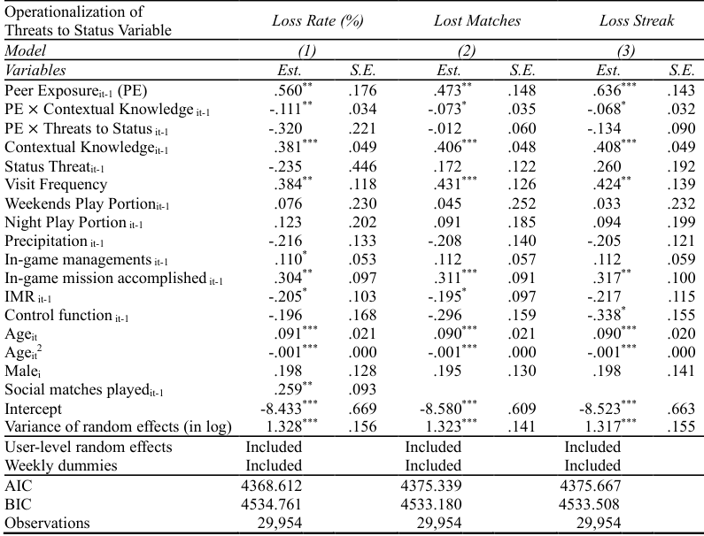

NOTE: complex table shown as an image of the PDF; the text below is a rough machine extraction and may be mis-aligned.

**extracted text (unreliable layout)**

Page 18

18

*G.2. Suspense as a potential moderator*

Insignificant moderation by ‘Threats to Status (% inferior matchesit−1)’ might be masked by another factor called suspense (i.e., uncertainty in match outcomes). Users may be more influenced when suspense is high and less influenced when suspense is low. Therefore, even if the competitive effect is present, it can be masked by these two different scenarios.

We explored the alternative approach in this analysis. According to Simonov et al. (2023), suspense can be defined as ‘… *the standard deviation of the next period’s belief about the final outcome of the entertainment product, reflecting viewers’ uncertainty about events that may occur*… (page 1-2)’. This implies that when outcome uncertainty is high, suspense increases, and when the outcome becomes pretty certain, suspense decreases.

Using granular observations of the esports video game CS:GO, Simonov et al. (2023) defined the suspense level of streamed content on Twitch.tv for each round 𝑡 as follows:

**equation / math rendering (image)**

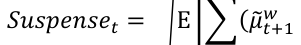

NOTE: contains mathematical notation; text above is the PDF text layer and symbols may be mis-extracted. Image shows the original.

**equation / math rendering (image)**

NOTE: contains mathematical notation; text above is the PDF text layer and symbols may be mis-extracted. Image shows the original.

**equation / math rendering (image)**

NOTE: contains mathematical notation; text above is the PDF text layer and symbols may be mis-extracted. Image shows the original.

𝑤

**equation / math rendering (image)**

NOTE: contains mathematical notation; text above is the PDF text layer and symbols may be mis-extracted. Image shows the original.

**equation / math rendering (image)**

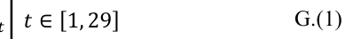

NOTE: contains mathematical notation; text above is the PDF text layer and symbols may be mis-extracted. Image shows the original.

where 𝜇𝑡 is a belief path and 𝜇̃𝑡

𝑤 is observed belief for event 𝑤∈ {Team A wins, Team B wins}. By construction, the measure increases when ‘… *uncertainty about the game outcome is high* … (page 8)’ (Simonov et al. 2023).

Following this idea, we compute the level of suspense experienced by each player 𝑖 at week 𝑡. The key point of distinction is that Simonov et al. (2023) did not define individual player (or viewer) level suspense, whereas we define it at the individual player level (*i* subscript). Specifically, for each social match played by player 𝑖 with the opponent player 𝑗, we propose that the uncertainty in match outcome (i.e., suspense) will be greater if the *i* and *j* are close to each other in terms of tiers. Contrastingly, the suspense will be lesser if player *i*’s tier is much higher (or lower) than player *j*. To capture these dynamics, we define suspense as follows:

**equation / math rendering (image)**

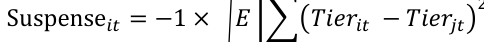

NOTE: contains mathematical notation; text above is the PDF text layer and symbols may be mis-extracted. Image shows the original.

2

**equation / math rendering (image)**

NOTE: contains mathematical notation; text above is the PDF text layer and symbols may be mis-extracted. Image shows the original.

𝑗

**equation / math rendering (image)**

NOTE: contains mathematical notation; text above is the PDF text layer and symbols may be mis-extracted. Image shows the original.

where 𝑇𝑖𝑒𝑟𝑖𝑡 is the observed tier of player 𝑖 in the game at week 𝑡. We multiply minus one to the root mean squared tier difference, as a smaller difference in tiers would suggest greater suspense (i.e., uncertainty in match outcome).

We then introduce this newly measured suspense variable in our main model as a moderator. If the suggested alternative scenario for competitive concern is at work, we should see that the positive and significant peer influence becomes more pronounced when suspense increases. In Table G3, we present the estimation results with this new moderation analysis. Column (1) reports the results when the suspense variable is operationalized as in equation G. (2). Column (2) presents a robustness check when we remove the 'square root' from equation G.(2). As we can see form Table G3, the peer effect is not significantly moderated by suspense. Thus, we conclude that peer influence in our context is more likely driven by uncertainty reduction (i.e.,

Page 19

19

informational influence) rather than by competitive concerns (i.e., suspense) experienced during the match.

Table G3: Does Peer Influence Become Stronger as Suspense (Outcome Uncertainty) Increases?

| Model | (1) |  | (2) |  |
| --- | --- | --- | --- | --- |
| Operationalization ofSuspense | Root Mean Squared Tier Difference |  | Mean Squared Tier Difference |  |
| Variables | Est . | S E . . | Est . | S E . . |
| Peer exposureit-1 (PE) | 059*** . | 013 . | 069*** . | 012 . |
| PE × Suspenseit-1 | 0020 . | 0023 . | 0001 -. | 0003 . |
| Suspenseit-1 | 023*** -. | 004 . | 002** -. | 001 . |
| Visit frequencyit-1 | 144*** . | 010 . | 148*** . | 010 . |
| Weekends play portionit-1 | 095*** . | 015 . | 095*** . | 015 . |
| Night play portionit-1 | 028* -. | 014 . | 030* -. | 014 . |
| Ageit2 | 204 -. | 178 . | 207 -. | 178 . |
| Ageit | 1 063 . | 924 . | 1 077 . | 936 . |
| Tenureit | 109*** -. | 025 . | 110*** -. | 026 . |
| Precipitationit | 001 . | 004 . | 001 . | 004 . |
| IMR it-1 | 023* -. | 011 . | 015 -. | 010 . |
| Control functionit-1 | 020 -. | 013 . | 031* -. | 013 . |
| Individual fixedeffects | Included |  | Included |  |
| Weekly fixed effects | Included |  | Included |  |
| R squared | 278 . |  | 278 . |  |

NOTE: table converted from PDF layout to HTML text; cell boundaries are reconstructed. See PDF if exact alignment matters.

Mean Squared Tier Difference Variables Est. S.E. Est. S.E. Peer exposureit-1 (PE) .059 ***.013 .069 ***.012 PE × Suspenseit-1 .0020 .0023 -.0001 .0003 Suspenseit-1 -.023 ***.004 -.002 ** .001 Visit frequencyit-1 .144 ***.010 .148 ***.010 Weekends play portionit-1 .095 ***.015 .095 ***.015 Night play portionit-1 -.028 * .014 -.030 * .014 Ageit<sup>2</sup> -.204 .178 -.207 .178 Ageit 1.063 .924 1.077 .936 Tenureit -.109 ***.025 -.110 ***.026 Precipitationit .001 .004 .001 .004 IMRit-1 -.023 * .011 -.015 .010 Control functionit-1 -.020 .013 -.031 * .013 Individual fixed effects Included Included Weekly fixed effects Included Included R squared .278 .278 Note: N=118,368. We use bootstrapped standard errors with 200 resamples. All moderators are centered on their means. *p<.05; **p<.01; ***p<.001. Finally, for robustness, we also consider relatively simpler operationalizations of suspense variables by just computing the number of social matches with opponents (1) with exactly the same tier and (2) with relatively similar tiers (± two tier differences) as alternative moderators. The expectation being that matches with tighter tier differences would create more suspense due to unpredictable match outcomes. We did not find significant moderation in these variables either, and the results are listed in Table G4.

Page 20

20

Table G4: Does Peer Influence Become Stronger as Suspense (Outcome Uncertainty) Increases?

| Model | (1) |  | (2) |  |
| --- | --- | --- | --- | --- |
| Operationalization ofSuspense | Matcheswith exactly same tier users |  | Matcheswith similar tier (± 2tiers)users |  |
| Variables | Est . | S E . . | Est . | S E . . |
| Peer exposureit-1 (PE) | 049*** . | 013 . | 033* . | 013 . |
| PE × Suspenseit-1 | 0007 -. | 0005 . | 0004 -. | 0003 . |
| Suspenseit-1 | 004** . | 001 . | 003*** . | 001 . |
| Visit frequencyit-1 | 151*** . | 010 . | 151*** . | 009 . |
| Weekends play portionit-1 | 097*** . | 015 . | 099*** . | 016 . |
| Night play portionit-1 | 031* -. | 014 . | 031** -. | 011 . |
| Ageit2 | 215 -. | 182 . | 217 -. | 186 . |
| Ageit | 1 120 . | 959 . | 1 123 . | 954 . |
| Tenureit | 109*** -. | 024 . | 109*** -. | 025 . |
| Precipitationit | 001 . | 003 . | 001 . | 003 . |
| IMR it-1 | 003 -. | 010 . | 002 . | 010 . |
| Control functionit-1 | 013 -. | 013 . | 002 -. | 014 . |
| Individual fixedeffects | Included |  | Included |  |
| Weekly fixed effects | Included |  | Included |  |
| R squared | 278 . |  | 278 . |  |

NOTE: table converted from PDF layout to HTML text; cell boundaries are reconstructed. See PDF if exact alignment matters.

Page 21

21

*G.3. Mid-status anxiety*

Another possibility is that peer influence with competitive concern may be non-linear, as suggested by Hu and Van den Bulte (2014). Peer influence may be strongest for those in middle status due to mid-status anxiety. We used the weekly recorded tier of each player to indicate their status and included both quadratic and linear terms of the status variable, interacting them with the peer exposure variable. If middle-status anxiety, a component of competitive concern, is present, the impact of peer exposure should be moderated in an inverted U-shaped manner by one’s status. As reported in Table G5, we do not find that one’s status or its square term significantly moderates the positive effect of peer exposure.

Table G5: Analysis for Mid-Status Anxiety following Hu and Van den Bulte (2014)

| Variables | Estimate |  | S E . . |
| --- | --- | --- | --- |
| Peer exposureit-1 (PE) | 068*** . |  | 012 . |
| Own statusit-1 | 00084 . |  | 00128 . |
| Own statusit-12 | 00036 -. |  | 00022 . |
| PE × Own statusit-1 | 00039 . |  | 00106 . |
| PE × Own statusit-12 | 00019 . |  | 00012 . |
| Visit frequencyit-1 | 150*** . |  | 009 . |
| Weekends play portionit-1 | 094*** . |  | 013 . |
| Night play portionit-1 | 032** -. |  | 011 . |
| Ageit2 | 209 -. |  | 200 . |
| Ageit | 1 088 . |  | 1 069 . |
| Tenureit | 094** -. |  | 030 . |
| Precipitationit | 001 . |  | 003 . |
| IMR it-1 | 010 -. |  | 009 . |
| Control functionit-1 | 032** -. |  | 012 . |
| Individual fixedeffects | Included |  |  |
| Weekly fixed effects | Included |  |  |
| R squared | 278 . |  |  |

NOTE: table converted from PDF layout to HTML text; cell boundaries are reconstructed. See PDF if exact alignment matters.

Note: N=118,368. We use bootstrapped standard errors with 200 resamples. The moderator is centered on its mean. *p<.05; **p<.01; ***p<.001.

Page 22

22

#### **WEB APPENDIX H:**

#### **Robustness Check: Alternative Sampling Criteria**

We confirm the robustness of our findings using alternative samples. First, we replicate the analyses with the original 4,000 players. Since approximately 7.5% of users have missing control variables, we exclude these variables from our replication. As shown in Table H1 below, the positive effect of peer exposure is replicated; however, it attenuates as one’s contextual knowledge increases, supporting the theory of informational influence. We use cumulative visits as a proxy for contextual knowledge. We also employ the percentage of inferior matches (where the player’s tier is lower than that of the opponents) in a manner consistent with our main analyses for mechanism tests.

Table H1: Replication with Original 4,000 Players Sample Variables Est. S.E. Peer Exposureit-1 .056*** .012 PE × Contextual Knowledge -.013*** .004 PE × Threats to Status .004 .017 Contextual Knowledgeit-1 -.068*** .010 Threats to Status .156*** .036 Visit frequencyit-1 .180*** .009 Weekends play portionit-1 .085*** .013 Night play portionit-1 -.038** .013 Tenureit -.057* .025 IMRit-1 -.007 .010 Control functionit-1 -.012 .013 Individual Fixed Effects Included Weekly Fixed Effects Included R squared .283

| Variables | Est . | S E . . |
| --- | --- | --- |
| Peer Exposureit-1 | 056*** . | 012 . |
| PE × Contextual Knowledge | 013*** -. | 004 . |
| PE ×Threats toStatus | 004 . | 017 . |
| Contextual Knowledgeit-1 | 068*** -. | 010 . |
| Threats to Status | 156*** . | 036 . |
| Visit frequencyit-1 | 180*** . | 009 . |
| Weekends play portionit-1 | 085*** . | 013 . |
| Night play portionit-1 | 038** -. | 013 . |
| Tenureit | -.057* | 025 . |
| IMR it-1 | 007 -. | 010 . |
| Control functionit-1 | 012 -. | 013 . |
| Individual FixedEffects | Included |  |
| Weekly Fixed Effects | Included |  |
| R squared | 283 . |  |

NOTE: table converted from PDF layout to HTML text; cell boundaries are reconstructed. See PDF if exact alignment matters.

Note: Observations is 128,000. We use bootstrapped standard errors with 200 resamples. We utilized cumulative visit frequency to measure contextual knowledge and the proportion of inferior social matches as indicators of threats to status. All moderators are centered on their means. *p<.05; **p<.01; ***p<.001.

Page 23

23

Next, we replicate the analyses with the top 1,131 players, who account for 95% of the firm’s revenues. This conditioning is done to exclude players who never contribute to the firm’s revenues under any circumstances. Such ‘always-free’ users are common in other freemiumbased services. As shown in Table H2, we continue to find evidence of peer exposure and the negative moderation of contextual knowledge. Contextual knowledge and threats to status variables are the same as Table H1.

Table H2: Replication with Top 1,131 Players Who Account for 95% of Revenues

| Variables | Est . | S E . . |
| --- | --- | --- |
| Peer Exposureit-1 | 081* . | 034 . |
| PE × Contextual Knowledge | 031*** -. | 009 . |
| PE ×Threats toStatus | 049 -. | 051 . |
| Contextual Knowledge | 151*** -. | 029 . |
| Threats to Status | 410*** . | 109 . |
| Visit frequencyit-1 | 371*** . | 029 . |
| Weekends play portionit-1 | 201*** . | 039 . |
| Night play portionit-1 | -.075* | 035 . |
| Ageit2 | 808 -. | 1 078 . |
| Ageit | 3 947 . | 6 752 . |
| Tenureit | -.197** | 069 . |
| Precipitationit | 012 . | 011 . |
| IMR it-1 | 004 . | 031 . |
| Control functionit-1 | 015 -. | 034 . |
| Individual FixedEffects | Included |  |
| Weekly Fixed Effects | Included |  |
| R squared | 249 . |  |

NOTE: table converted from PDF layout to HTML text; cell boundaries are reconstructed. See PDF if exact alignment matters.

Note: Observations is 36,192. We use bootstrapped standard errors with 200 resamples. We utilized cumulative visit frequency to measure contextual knowledge and the proportion of inferior social matches as indicators of threats to status. All moderators are centered on their means. *p<.05; **p<.01; ***p<.001.

Page 24

24

#### **WEB APPENDIX I:**

#### **Robustness Check: Test for Normative Influence**

To empirically examine normative influence (Deutsch and Gerard 1955) as a possible mechanism for the identified peer effect, we perform additional analyses. Since the need for conformity to social norms is known to increase as one’s peer network expands (Iyengar, Van den Bulte and Lee 2015; Toker-Yildiz et al. 2017; Zhang, Liu and Chen 2015), we investigate whether the magnitude of the estimated peer effect varies with the size of the social network. We use the number of unique social matches and the number of unique peers with whom players have interacted as proxies for social network size. Cumulative visits serve as a proxy for contextual knowledge. Additionally, we employ the percentage of inferior matches (where the player’s tier is lower than that of the opponents) as a proxy for threats to status in a manner consistent with our main analyses for mechanism tests.

In Table I, we continue to observe evidence of informational influence through the negative and significant moderation of contextual knowledge; however, we find no evidence supporting normative influence.

Table I: Test for Normative Influence as a Possible Underlying Mechanism

| OperationalizationofSocialNetworkSize |  | (1) NumberofSocial Matchesit-1 | (2) NumberofStranger Peers Interacted it-1 |
| --- | --- | --- | --- |
| Variables | Test for | Est S E . . . | Est S E . . . |
| Peer Exposureit-1 PE × Contextual Knowledge | InformationalInfluence | 003 013 . . 013** 004 -. . | 002 013 . . 013** 005 -. . |
| PE ×Threats toStatus | CompetitiveConcern | 007 021 -. . | 007 021 -. . |
| PE × Social NetworkSize Contextual Knowledge Threats to Status Social Network Size Visit frequencyit-1 Weekends play portionit-1 Night play portionit-1 Ageit2 Ageit Tenureit Precipitationit IMR it-1 C… | NormativeInfluence | 0001 000 -. . 069*** 010 -. . 183*** 041 . . 004*** 001 . . 167*** 010 . . 094*** 014 . . 028* 013 -. . 211 175 -. . 1 125 891 . . 074** 027 -. . 001 003 . . 005 010 . . 028* 014 . . | 0002 000 -. . 069*** 011 -. . 183*** 041 . . 004*** 001 . . 167*** 009 . . 093*** 015 . . 028* 011 -. . 208 184 -. . 1 115 941 . . 074** 027 -. . 001 004 . . 005 010 . . 029* 013 . . |
| Individual FixedEffects Weekly Fixed Effects |  | Included Included | Included Included |
| R squared |  | 280 . | 280 . |

NOTE: table converted from PDF layout to HTML text; cell boundaries are reconstructed. See PDF if exact alignment matters.

Page 25

25

#### **WEB APPENDIX J:**

#### **Robustness Check: Alternative Functional Form (Poisson Fixed Effects Model)**

To account for the frequent occurrence of non-purchases in free-to-play games, we re-estimate the main model with a Poisson fixed effect model using purchase frequency as a dependent variable (Wang and Goldfarb 2017). We employ the percentage of inferior matches—where the player’s tier is lower than that of the opponents—as a proxy for threats to status. As proxies for contextual knowledge, we use cumulative game visits. In Table J, we find that the impact of peers diminishes as one’s contextual knowledge increases. However, the main effect of peer exposure is insignificant. Since the high-order interaction term yields a significant and consistent effect, we consider the results to still be within the range of robustness.

| Variables | Est . | S E . . |
| --- | --- | --- |
| Peer Exposureit-1 | 100 . | 080 . |
| PE XContextual Knowledge | 052** -. | 018 . |
| PE XThreats toStatus | 085 -. | 089 . |
| Contextual Knowledge | 370*** -. | 083 . |
| Threats to Status | 494* . | 233 . |
| Visit frequencyit-1 | 813*** . | 073 . |
| Weekends play portionit-1 | 520*** . | 136 . |
| Night play portionit-1 | 164 . | 127 . |
| Ageit2 | 732 -. | 1 430 . |
| Ageit | 3 717 . | 8 259 . |
| Tenureit | 216 -. | 166 . |
| Precipitationit | 020 . | 026 . |
| IMR it-1 | 070 . | 079 . |
| Control functionit-1 | 064 -. | 084 . |
| Individual FixedEffects | Included |  |
| Weekly Fixed Effects | Included |  |
| Pseudo R squared | 614 . |  |

NOTE: table converted from PDF layout to HTML text; cell boundaries are reconstructed. See PDF if exact alignment matters.

Page 26

26

#### **WEB APPENDIX K:**

#### **Robustness Check: Need for Reloading Game Items**

| Variables | Est . | S E . . |
| --- | --- | --- |
| Peer Exposureit-1 | 170*** . | 010 . |
| PE × Contextual Knowledge | 013** -. | 004 . |
| PE ×Threats toStatus | 028 -. | 021 . |
| Contextual Knowledge | 022* -. | 009 . |
| Threats to Status | 241*** . | 044 . |
| Social matches participated it-1 | 003*** . | 000 . |
| Weekends play portionit-1 | 164*** . | 014 . |
| Night play portionit-1 | 073*** . | 010 . |
| Ageit2 | 206 -. | 173 . |
| Ageit | 1 112 . | 931 . |
| Tenureit | 085** -. | 027 . |
| Precipitationit | 001 . | 004 . |
| IMR it-1 | 131*** -. | 008 . |
| Control functionit-1 | 138*** -. | 011 . |
| Individual FixedEffects | Included |  |
| Weekly Fixed Effects | Included |  |
| R squared | 277 . |  |

NOTE: table converted from PDF layout to HTML text; cell boundaries are reconstructed. See PDF if exact alignment matters.

Note: Observations is 36,192. We use bootstrapped standard errors with 200 resamples. We utilized cumulative visit frequency to measure contextual knowledge and the proportion of inferior social matches as indicators of threats to status. All moderators are centered on their means. *p<.05; **p<.01; ***p<.001.

Page 27

27

#### **WEB APPENDIX L: Heterogeneity in Item Salience**

In addition to the analyses reported on product salience heterogeneity, we explore the heterogeneity in what the focal users purchase using the same information. Specifically, we compute the ratio of the purchase amount ($) for highly salient items to the total purchase amount ($) +1 as follows:

**equation / math rendering (image)**

NOTE: contains mathematical notation; text above is the PDF text layer and symbols may be mis-extracted. Image shows the original.

**equation / math rendering (image)**

NOTE: contains mathematical notation; text above is the PDF text layer and symbols may be mis-extracted. Image shows the original.

( 𝑃𝑢𝑟𝑐ℎ𝑎𝑠𝑒($)𝑖𝑡

**equation / math rendering (image)**

NOTE: contains mathematical notation; text above is the PDF text layer and symbols may be mis-extracted. Image shows the original.

𝐻𝑖𝑔ℎ 𝑆𝑎𝑙𝑖𝑒𝑛𝑐𝑒+ 𝑃𝑢𝑟𝑐ℎ𝑎𝑠𝑒($)𝑖𝑡

**equation / math rendering (image)**

NOTE: contains mathematical notation; text above is the PDF text layer and symbols may be mis-extracted. Image shows the original.

**equation / math rendering (image)**

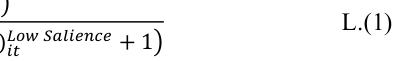

NOTE: contains mathematical notation; text above is the PDF text layer and symbols may be mis-extracted. Image shows the original.

The proposed ratio-style dependent variable would capture the relative share of focal player’s item purchases with greater salience to the total purchases made in week t. To prevent division by zero, one is added to the denominator. We replicate the same analysis we performed for item salience with this new dependent variable. Table L reports the estimation results.

Table L: Peer Influence by Item Salience Variables Est. S.E.

| Variables | Est . | SE . . |
| --- | --- | --- |
| Peer exposure 𝑖𝐻 𝑡𝑖 −𝑔 1ℎ 𝑆𝑎𝑙𝑖𝑒𝑛𝑐𝑒 (𝑃𝐸: 𝐻𝑖𝑔ℎ) | 032*** . | 005 . |
| Peer exposure𝑖𝐿 𝑡𝑜 −𝑤 𝑆𝑎𝑙𝑖𝑒𝑛𝑐𝑒 (𝑃𝐸: 𝐿𝑜𝑤) 1 | -.057*** | 014 . |
| Visit frequencyit-1 | 038*** . | 002 . |
| Weekends play portionit-1 | 016*** . | 003 . |
| Night play portionit-1 | -.010*** | 003 . |
| Ageit2 | 035 -. | 049 . |
| Ageit | 185 . | 263 . |
| Tenureit | -.017* | 007 . |
| Precipitationit | 001 . | 001 . |
| IMR it-1 | 004 . | 003 . |
| Control Functionit-1 (PE:High) | -.026*** | 005 . |
| Control Functionit-1 (PE:Low) | 064*** . | 014 . |
| Individualfixedeffects | Included |  |
| Weeklyfixedeffects | Included |  |
| Rsquared | 288 . |  |

NOTE: table converted from PDF layout to HTML text; cell boundaries are reconstructed. See PDF if exact alignment matters.

𝐿𝑜𝑤 𝑆𝑎𝑙𝑖𝑒𝑛𝑐𝑒 (𝑃𝐸: 𝐿𝑜𝑤) -.057*** .014 Visit frequencyit-1 .038*** .002 Weekends play portionit-1 .016*** .003 Night play portionit-1 -.010*** .003 Ageit<sup>2</sup> -.035 .049 Ageit .185 .263 Tenureit -.017* .007 Precipitationit .001 .001 IMRit-1 .004 .003 Control Functionit-1 (PE:High) -.026*** .005 Control Functionit-1 (PE:Low) .064*** .014 Individual fixed effects Included Weekly fixed effects Included R squared .288 Note: Observations is 118,368. We use bootstrapped standard errors with 200 resamples. *p<.05; **p<.01; ***p<.001. We found a positive and significant influence of peer exposure to high salience items (𝛽= .032, p<.001), meaning more exposure to peers’ use of salient game items increases the share of the same kinds of items among purchased items. We also found a negative and significant influence of peer exposure to low salience items (𝛽= -.057, p<.001). This is consistent with our theorization that when focal users are exposed to peers’ uses of low-saliency items, the peer influence becomes weaker, leading to a drop in the ratio of salient item purchases. This does not necessarily mean that focal players buy more low-salience items; rather, it indicates a diminished

Page 28

28

influence from peers on the purchase of salient items. The negative effect of low-salience items could also be partly driven by instances where the focal player decides not to purchase anything (i.e., reduced peer influence), resulting in the dependent variable becoming zero.

#### *References*

Barron, Kyle, Edward Kung, and Davide Proserpio (2021), “The Effect of Home-Sharing on

House Prices and Rents: Evidence from Airbnb,” *Marketing Science*, 40(1), 23–47.

Bramoullé, Yann, Habiba Djebbari, and Bernard Fortin (2009), “Identification of Peer Effects

through Social Networks,” *Journal of Econometrics*, 150(1), 41–55.

Deutsch, Morton and Harold B. Gerard (1955), “A Study of Normative and Informational Social

Influences upon Individual Judgment,” *The Journal of Abnormal and Social Psychology*, 51(3), 629–36.

Gu, Xian and P.K. Kannan (2021), “The Dark Side of Mobile App Adoption: Examining the

Impact on Customers’ Multichannel Purchase,” *Journal of Marketing Research*, 58(2), 246–64.

Han, Kyuhong, Vikas Mittal, and Yan Zhang (2017), “Relative Strategic Emphasis and Firm-

Idiosyncratic Risk: The Moderating Role of Relative Performance and Demand Instability,” *Journal of Marketing*, 81(4), 25–44.

Haviv, Avery, Yufeng Huang, and Nan Li (2020), “Intertemporal Demand Spillover Effects on

Video Game Platforms,” *Management Science*, 66(10), 4788–4807.

Iyengar, Raghuram, Christophe Van den Bulte, and Jae Young Lee (2015), “Social Contagion in

New Product Trial and Repeat,” *Marketing Science*, 34(3), 408–29.

Papies, Dominik, Peter Ebbes, and Harald J. Van Heerde (2017), “Addressing Endogeneity in

Marketing Models,” in *Advanced Methods for Modeling Markets*, Cham: Springer International Publishing, 581–627, http://link.springer.com/10.1007/978-3-319-53469- 5_18.

Rossi, Peter E. (2014), “Invited Paper—Even the Rich Can Make Themselves Poor: A Critical

Examination of IV Methods in Marketing Applications,” *Marketing Science*, 33(5), 655– 72.

Sanderson, Eleanor and Frank Windmeijer (2016), “A Weak Instrument F-Test in Linear IV

Models with Multiple Endogenous Variables,” *Journal of Econometrics*, 190(2), 212–21.

Shen, Qiaowei and Ping Xiao (2014), “McDonald’s and KFC in China: Competitors or

Companions?,” *Marketing Science*, 33(2), 287–307.

Page 29

29

Shi, Huanhuan, Rajdeep Grewal, and Shrihari Sridhar (2021), “Organizational Herding in

Advertising Spending Disclosures: Evidence and Mechanisms,” *Journal of Marketing Research*, 58(3), 515–38.

Sunder, Sarang, Kihyun Hannah Kim, and Eric A. Yorkston (2019), “What Drives Herding

Behavior in Online Ratings? The Role of Rater Experience, Product Portfolio, and Diverging Opinions,” *Journal of Marketing*, 83(6), 93–112.

Toker-Yildiz, Kamer, Minakshi Trivedi, Jeonghye Choi, and Sue Ryung Chang (2017), “Social

Interactions and Monetary Incentives in Driving Consumer Repeat Behavior,” *Journal of Marketing Research*, 54(3), 364–80.

Wang, Kitty and Avi Goldfarb (2017), “Can Offline Stores Drive Online Sales?,” *Journal of*

*Marketing Research*, 54(5), 706–19.

Wooldridge, Jeffrey M. (2015), “Control Function Methods in Applied Econometrics,” *Journal*

*of Human Resources*, 50(2), 420–45.

Zhang, Jurui, Yong Liu, and Yubo Chen (2015), “Social Learning in Networks of Friends versus

Strangers,” *Marketing Science*, 34(4), 573–89.